# My SpotifyR report

Author

Maša Maletić

# Loreen

Lorine Zineb Nora Talhaoui, known profesionally as Loreen is a Swedish singer and songwriter. Born on 16th of October 1983, which makes her a libra, important to mention as she is known for her love of astrology.

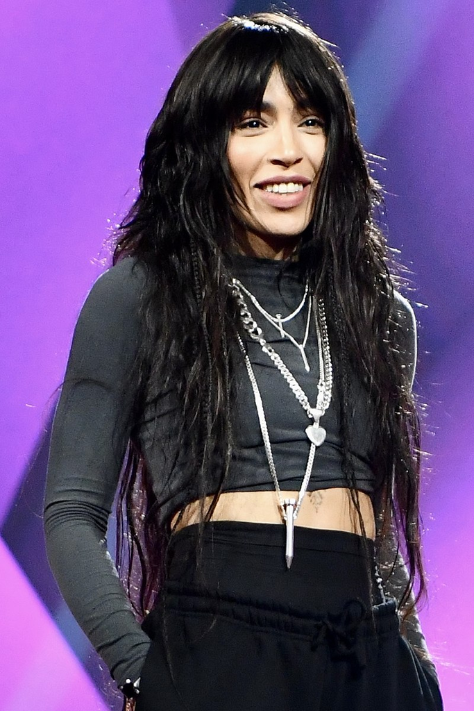

### Eurovision

Representing Sweden she has won the Eurovision Song Contest twice - in 2012 and 2023 - with the songs “Euphoria” and “Tattoo” respectively.

https://youtu.be/Pfo-8z86x80?feature=shared

https://youtu.be/BE2Fj0W4jP4?feature=shared

### Fan base

She’s commonly referred to as “mother” who is “mothering”, within her fandom, as well as the Eurovision fandom.

Her nails are a well known statement and a popular attraction when it comes to her concerts, performance pieces, and the overall branding.

## Data Analysis

### Import Data

```r
# These are packages I need for the analysis
library(ggplot2)
library(dplyr)

# Import data into df
df <- read.csv("~/Desktop/Loreen.csv")
```

### Glance of the data frame

```r
# Slice 3 random records in the dataframe
df |> dplyr::slice_sample(n=3) |> knitr::kable(digits = 2)
```

| artist_name | track_name | track_number | album_name | album_release_year | album_release_date | valence | energy | danceability | loudness | tempo | speechiness | instrumentalness | liveness | key_name | mode_name | key_mode | duration_ms |
| --- | --- | --- | --- | --- | --- | --- | --- | --- | --- | --- | --- | --- | --- | --- | --- | --- | --- |
| Loreen | Breaking Robot | 10 | Heal (2013 Edition) | 2013 | 2013-05-31 | 0.43 | 0.72 | 0.44 | -6.43 | 126.89 | 0.14 | 0 | 0.09 | G | major | G major | 209066 |
| Loreen | Euphoria | 4 | Heal | 2012 | 2012-10-19 | 0.11 | 0.68 | 0.52 | -5.41 | 132.15 | 0.04 | 0 | 0.06 | B | minor | B minor | 214133 |
| Loreen | Sober | 8 | Heal (2013 Edition) | 2013 | 2013-05-31 | 0.32 | 0.83 | 0.59 | -5.49 | 120.94 | 0.07 | 0 | 0.11 | C# | major | C# major | 217306 |

### Data preparation

There are some duplicated tracks and numerous versions of her greatest hit “Euphoria”, I decided to only leave the original track for each song therefore I’ve cleaned the data set accordingly.

```r
# Filter out track names that include "Remix" or "Version"
df <- df |> filter(!grepl("Remix|Version", track_name))
# Filter out album names that include "The Alternative Mixes"
df <- df |> filter(!grepl("The Alternative Mixes", album_name))
# For duplicates I made a new dataset as it will help in further analysis
df2 <- df |> distinct(track_name, .keep_all = TRUE)
```

### Album analysis (speechiness, loudness and energy)

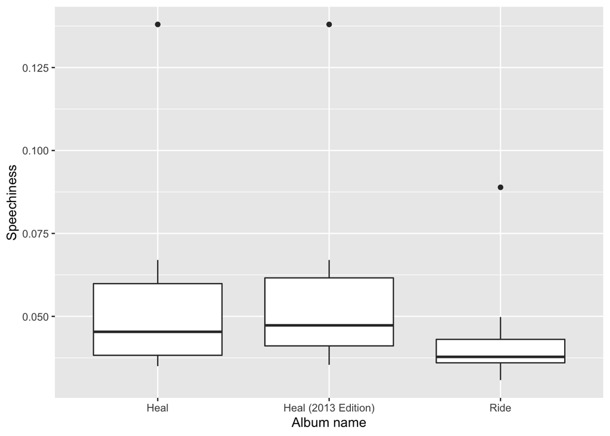

```r
# Change album name from character to factor before plotting
df$album_name <- as.factor(df$album_name)
# Plot a boxplot
ggplot(df, aes(x=album_name, y=speechiness))+
  geom_boxplot()+
  labs(x="Album name", y="Speechiness")
```

2013 has the highest medium - her ‘talkative’ year?

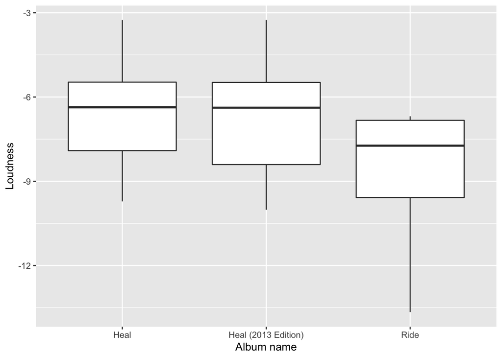

```r
ggplot(df, aes(x=album_name, y=loudness))+
  geom_boxplot()+
  labs(x="Album name", y="Loudness")
```

Her albums have gotten less loud over the years (2012, 2013, 2017).

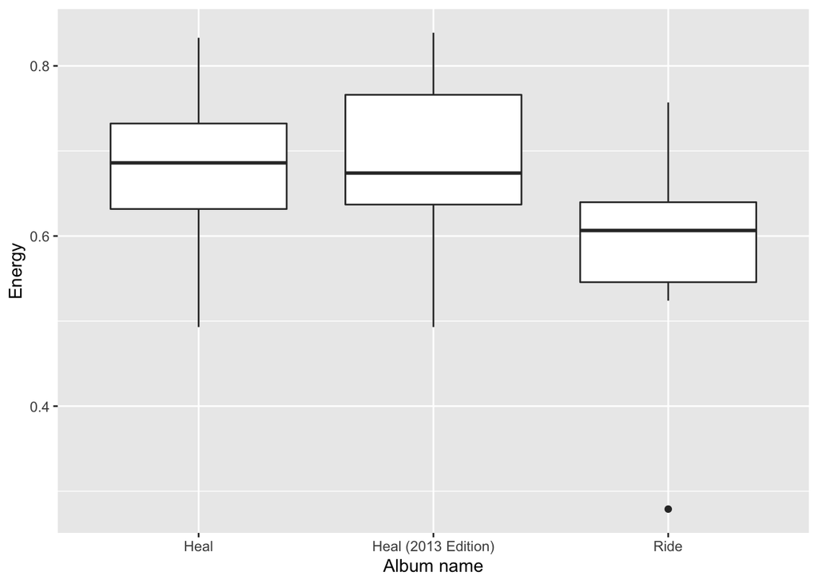

```r
ggplot(df, aes(x=album_name, y=energy))+
  geom_boxplot()+
  labs(x="Album name", y="Energy")
```

Follows the same pattern as loudness which makes sense.

### Is Loreen’s music good for dancing?

```r
# Find top 3 songs for dancing But first remove records with the same track names
df2 |> slice_max(danceability, n=3) |> dplyr::select(track_name, album_name, album_release_year, danceability) |> knitr::kable(digits = 2)
```

| track_name | album_name | album_release_year | danceability |
| --- | --- | --- | --- |
| Do We Even Matter | Heal (2013 Edition) | 2013 | 0.63 |
| See You Again | Heal | 2012 | 0.62 |
| Sober | Heal (2013 Edition) | 2013 | 0.59 |

https://youtu.be/WmiRvaSfRZA?feature=shared

Makes sense considering earlier boxplot analysis.

This makes me think most of her songs will be sad, Let’s explore that.

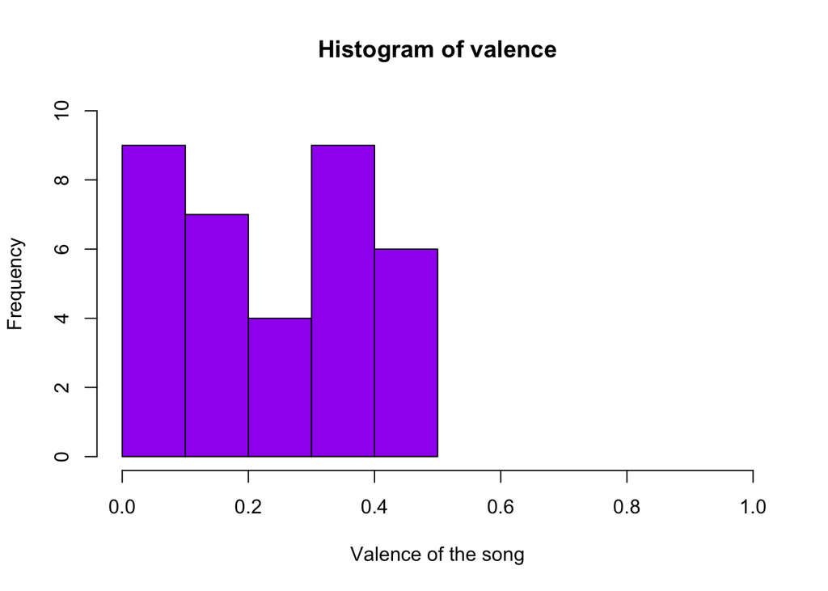

```r
hist(df$valence, main= "Histogram of valence", xlab="Valence of the song", ylab="Frequency", col = "purple", xlim = c(0, 1), ylim = c(0,10), nclass = 5)
```

Let’s also see her top 3 LEAST energetic songs.

```r
df2 |> slice_min(energy, n=3) |> dplyr::select(track_name, album_name, album_release_year, energy) |> knitr::kable(digits = 2)
```

| track_name | album_name | album_release_year | energy |
| --- | --- | --- | --- |
| ’71 Charger (Strings) | Ride | 2017 | 0.28 |
| Do We Even Matter | Heal (2013 Edition) | 2013 | 0.49 |
| Heal (feat. Blanks) | Heal (2013 Edition) | 2013 | 0.50 |

And top 3 most energetic songs.

```r
df2 |> slice_max(energy, n=3) |> dplyr::select(track_name, album_name, album_release_year, energy) |> knitr::kable(digits = 2)
```

| track_name | album_name | album_release_year | energy |
| --- | --- | --- | --- |
| We Got The Power | Heal (2013 Edition) | 2013 | 0.84 |
| Sober | Heal (2013 Edition) | 2013 | 0.83 |
| Sidewalk | Heal (2013 Edition) | 2013 | 0.83 |